# WB - Praca domowa 5

autor: Paulina Przybyłek

```python
import numpy as np
import pandas as pd
import dalex as dx
import pickle
import warnings
warnings.filterwarnings('ignore')
```

## Wczytanie zbioru danych *heart* oraz modelu

Wykorzystamy nasz stworzony zbiór danych, który opisany został przy drugiej pracy domowej, i modele: Random Forest, SVC oraz Naive Bayes. Głównym modelem w projekcie jest model lasu losowego.

```python
# wczytujemy treningowy zbiór danych - na treningowym model został nauczony
data = pd.read_csv('heart_train.csv')
data.head()
```

|  | age | sex | trestbps | chol | fbs | restecg | thalach | exang | oldpeak | ca | ... | thal_fd | thal_rd | slope_up | slope_flat | slope_down | cp_ta | cp_aa | cp_np | cp_a | target |
| --- | --- | --- | --- | --- | --- | --- | --- | --- | --- | --- | --- | --- | --- | --- | --- | --- | --- | --- | --- | --- | --- |
| 0 | 56 | 1 | 125 | 249 | 1 | 1 | 144 | 1 | 1.2 | 1 | ... | 0 | 0 | 0 | 1 | 0 | 1 | 0 | 0 | 0 | 1 |
| 1 | 44 | 1 | 112 | 290 | 0 | 1 | 153 | 0 | 0.0 | 1 | ... | 0 | 0 | 1 | 0 | 0 | 1 | 0 | 0 | 0 | 1 |
| 2 | 62 | 0 | 140 | 394 | 0 | 1 | 157 | 0 | 1.2 | 0 | ... | 0 | 0 | 0 | 1 | 0 | 1 | 0 | 0 | 0 | 0 |
| 3 | 35 | 1 | 120 | 198 | 0 | 0 | 130 | 1 | 1.6 | 0 | ... | 0 | 1 | 0 | 1 | 0 | 1 | 0 | 0 | 0 | 1 |
| 4 | 56 | 0 | 140 | 294 | 0 | 1 | 153 | 0 | 1.3 | 0 | ... | 0 | 0 | 0 | 1 | 0 | 0 | 1 | 0 | 0 | 0 |

5 rows × 21 columns

```python
target_train = data.target.values
data_train = data.drop(['target'], axis = 1)
```

```python
rf = pickle.load(open('./Modele/random_forest', 'rb'))
nb = pickle.load(open('./Modele/naive_bayes', 'rb'))
```

```python
# wczytany model SVC z pickle nie działa jakoś poprawnie, dlatego tworzymy go tutaj
from sklearn.svm import SVC
from sklearn.preprocessing import StandardScaler
from sklearn.pipeline import Pipeline
svc = Pipeline(
    [
        ('standardscaler', StandardScaler()),
        ('SVC', SVC( C = 0.5, random_state=1, probability=True))
    ]
)
svc.fit(data_train, target_train)
```

```
Pipeline(steps=[('standardscaler', StandardScaler()),
                ('SVC', SVC(C=0.5, probability=True, random_state=1))])
```

## Zbudowanie Explainer'ów na podstawie modeli

Zanim przejdziemy do pracy potrzebujemy stworzyć explainery oparte o modele, które chcemy rozważać. Postanowiono zrobić to w oddzielnej sekcji, aby potem pokazywać czytelniej wyniki globalnych wyjaśnień.

```python
explainer_rf = dx.Explainer(rf, data_train, target_train, label = "Random Forest")
explainer_nb = dx.Explainer(nb, data_train, target_train, label = "Naive Bayes")
explainer_svc = dx.Explainer(svc, data_train, target_train, label = "SVC")
```

```
Preparation of a new explainer is initiated

  -> data              : 242 rows 20 cols
  -> target variable   : 242 values
  -> model_class       : sklearn.ensemble._forest.RandomForestClassifier (default)
  -> label             : Random Forest
  -> predict function  : <function yhat_proba_default at 0x7f60dbadc7b8> will be used (default)
  -> predict function  : Accepts pandas.DataFrame and numpy.ndarray.
  -> predicted values  : min = 0.0322, mean = 0.46, max = 0.988
  -> model type        : classification will be used (default)
  -> residual function : difference between y and yhat (default)
  -> residuals         : min = -0.738, mean = -0.00088, max = 0.81
  -> model_info        : package sklearn

A new explainer has been created!
Preparation of a new explainer is initiated

  -> data              : 242 rows 20 cols
  -> target variable   : 242 values
  -> model_class       : sklearn.naive_bayes.GaussianNB (default)
  -> label             : Naive Bayes
  -> predict function  : <function yhat_proba_default at 0x7f60dbadc7b8> will be used (default)
  -> predict function  : Accepts pandas.DataFrame and numpy.ndarray.
  -> predicted values  : min = 1.59e-08, mean = 0.439, max = 1.0
  -> model type        : classification will be used (default)
  -> residual function : difference between y and yhat (default)
  -> residuals         : min = -1.0, mean = 0.0197, max = 1.0
  -> model_info        : package sklearn

A new explainer has been created!
Preparation of a new explainer is initiated

  -> data              : 242 rows 20 cols
  -> target variable   : 242 values
  -> model_class       : sklearn.svm._classes.SVC (default)
  -> label             : SVC
  -> predict function  : <function yhat_proba_default at 0x7f60dbadc7b8> will be used (default)
  -> predict function  : Accepts pandas.DataFrame and numpy.ndarray.
  -> predicted values  : min = 0.0525, mean = 0.446, max = 0.982
  -> model type        : classification will be used (default)
  -> residual function : difference between y and yhat (default)
  -> residuals         : min = -0.934, mean = 0.0127, max = 0.915
  -> model_info        : package sklearn

A new explainer has been created!
```

## Dla wybranych zmiennych ze zbioru danych policz Partial Dependence Profiles (PDP)

Na początku przedstawiono profile PD, przy czym podzielono to na dwie części:

- skupiającą się na modelu głównym i pokazaniu dla niego profili PD z parametrem `geom="profiles"`
- części porównawczej wszystkich modeli na podstawie profili PD

W odpowiednich podsekcjach znajdują się opisane podpunkty zadania.

```python
pdp_rf = explainer_rf.model_profile(random_state=0)
pdp_nb = explainer_nb.model_profile(random_state=0)
pdp_svc = explainer_svc.model_profile(random_state=0)
```

### Główny model projektu - Random Forest

Uwaga: zamiast wywołania wstawiono screeny, poniważ plik przekroczył rozmiar dopuszczalny na githubie.

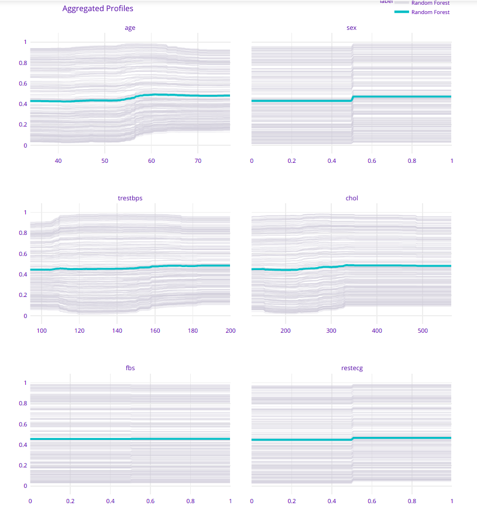

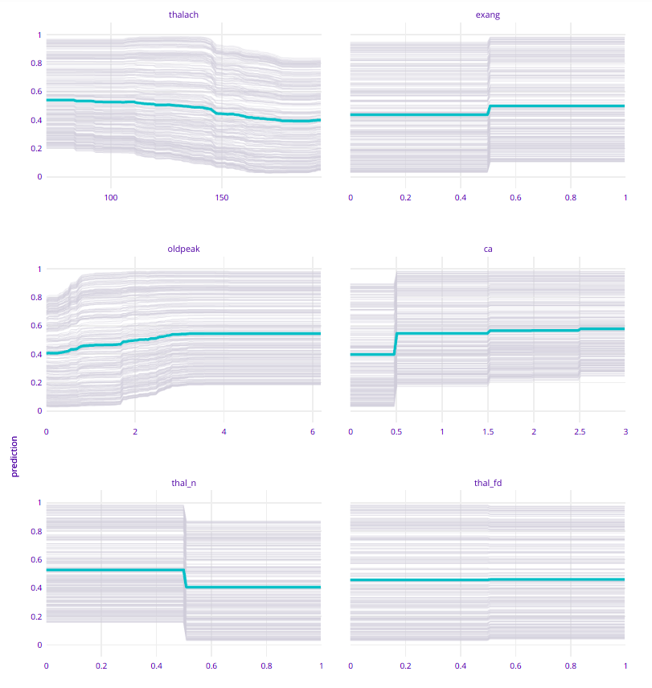

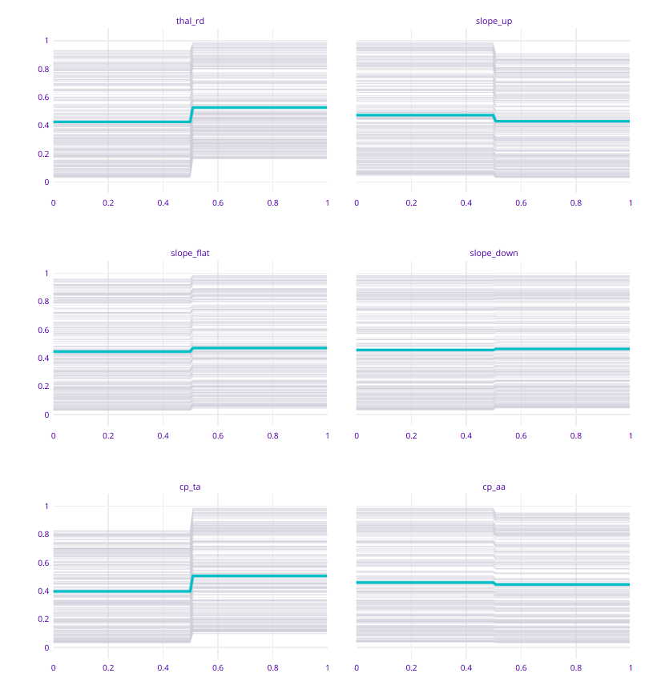

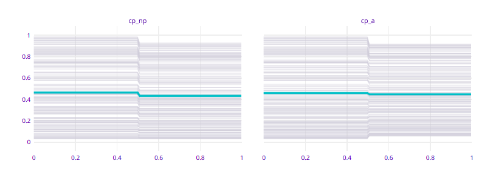

Patrząc na szare wyniki w tle każdej obserwacji mamy zajęte prawie całe pole możliwych wartości, dzieje się to dla każdej zmiennej. Nie jest to szczególnie dziwne, kiedy pomyślimy, że mamy dane medyczne dotyczące osób w dużym zakresie wiekowym i z różnymi objawami. Wartości PDP wydają się z tego powodu dość 'płaskie'. Jednak patrząc na te wykresy możemy zauważyć jakie zmienne mają większe skoki albo chociaż przyjrzeć się ogólnemu wpływowi zmiennej.

I tak zawsze predykcja rośnie wraz ze wzrostem wieku, z byciem mężczyzną, z gorszym wynikiem EKG (zmienna restecg, oldpeak, slope_flat i slope_down), z niższym tętnem, bólem w katce typowym dla choroby wieńcowej, wadą serca czy większej liczbie uwapnień. Są to typowe rzeczy, które w ogólności taki powinny mieć wpływ również z punktu medycznego.

### Porównanie wszystkich rozważanych modeli

Jednak profile PD są ciekawsze, jeśli chodzi o porównania modeli. Dlatego pomiżej przedstawiono te profile dla wczytanych modeli: Random Forest, Naive Bayes oraz SVC.

```python
pdp_rf.plot([pdp_nb, pdp_svc])
```

[interactive chart not shown]

Naive Bayes oraz SVC są liniowe na wykresach, natomiast Random Forest jest 'schodkowy'. W większości przypadków wykresy pokrywają się. Większe różnice pojawią się w przypadku zmiennej oldpeak, gdzie model Naive Bayes bardzo mocno ocenił wpływ tej zmiennej na predykcję w przypadku jej dużych wartości. Reszta przypadków jest bardzo zbliżona, bądź troszkę wykresy liniowe są odchylone na krańcach.

**Co ciekawego można zauważyć?**

- model SVC jest dość płaski dla wieku, chociaż wiemy że z wiekiem są większe szanse na chorobę oraz model lasu losowego również wychwytuje ten wzrost predykcjipowyżej 55 roku życia.
- w profilach PD cholesterol nie wydaje się znaczącą zmienną, chociaż podczas wyjaśnień globalnych przy użyciu permutacyjnej ważności zmiennej okazywało się, że miał on większy wpływ niż spora część zmiennych (przynajmniej dla Random Forest, dla którego tutaj troszkę on odstaje, jednak nie na tyle, aby wysnuć taki sam wniosek).
- tętno, uwapnienie, oldpeak, exang czy występowanie wady serca czy bólu serca dalej są znaczące jak przy poprzednich wyjaśnieniach - można zauważyć większe znaczenie oldpeak, co zakładaliśmmy, ale dotychczas wyniki lokalnych wyjaśnień nie były tak wyraźne.
- w permutacyjnej ważności zmiennych okazało się, że dla każdego modelu to ca jest najbardziej znaczące, do tamtej pory nie uważaliśmy tego za tak ważne. Mogło się tak wydarzyć, ponieważ ca można potraktować jako 0 - jest ok i 1-3 - nie jest dobrze, stąd permutacja mogła pokazać ważność tej zmiennej, bo danie osobie z 0 jakiejkolwiek wartości podbijało jego predykcję. Tuatj znów ca jest ważne, ale widać w przypadku modelu lasu losowego, że największa różnica jest między 0 a 1, a potem mamy już małe zmiany. Dla liniowych wykresów już takich wniosków byśmy nie zauważyli, jest tu jedynie widoczny wzrost predykcji wraz z większym uwapnieniem.
- typical angina, czyli ból powodujący najczęściej chorobę wieńcową również jest zauważalny w swojej ważności.

Podsumowując, do bardziej rzucających się w oczy zmiennych można zaliczyć tętno, oldpeak, uwapnienie, cp_ta (typical angina), występowanie wady serca bądź nie (thal_n, thal_rd). Ich ważność przejawiła się w trakcie innych wyjaśnień. Naszym zdaniem z medycznego punktu widzenia wiek oraz płeć również są ważne (chociaż może nie tak bardzo jak reszta), model lasu losowego wyłapał zależność predykcji od wieku, natomiast inne modele już niekoniecznie, szczególnie mowa tu o SVC. Możemy się tylko cieszyć, że nasz wybrany model główny bierze pod uwagę takie rzeczy, które z punktu medycznego również są ważne.

Poniżej przedstawiono profile PD dla zmiennych wymienionych w podsumowaniu.

```python
var = ['thalach', 'oldpeak', 'ca', 'cp_ta', 'thal_n', 'thal_rd', 'age', 'sex']
pdp_rf2 = explainer_rf.model_profile(random_state=0, variables=var)
pdp_nb2 = explainer_nb.model_profile(random_state=0, variables=var)
pdp_svc2 = explainer_svc.model_profile(random_state=0, variables=var)
```

```python
pdp_rf2.plot([pdp_nb2, pdp_svc2])
```

[interactive chart not shown]

## Dla wybranych zmiennych ze zbioru danych policz Accumulated Local Dependence (ALE)

Następnie przechodząc od profili PD zajmiemy się porównaniem modeli za pomocą profili ALE, być może wyłapiemy jakieś różnice. Co ważne profile ALE są odporte na korelacje zmiennych w porównaniu do profili PD.

```python
ale_rf = explainer_rf.model_profile(type = 'accumulated', random_state=0)
ale_nb = explainer_nb.model_profile(type = 'accumulated', random_state=0)
ale_svc = explainer_svc.model_profile(type = 'accumulated', random_state=0)
```

```python
ale_rf.plot([ale_nb, ale_svc])
```

[interactive chart not shown]

Mała uwaga: zmienne są ukazane w innej kolejności niż do tej pory, co może niektórym utrudnić ocenianie wpływu zmiennych.

**Jakie ciekawe rzeczy tu widać, które być może PDP nie pokazał?**

- Naive Bayes pokrywa się teraz z Random Forest w przypadku wieku.
- również dla Naive Bayes mamy duży spadek dla cp_a=1, który oznacza brak bólu, czyli model ma bardzo dużą pewność co do braku choroby. Przypominając, dla tego modelu w premutacyjnych ważnościach zmiennych to właśnie typical angina była najważniejsza, która oznacza ból skorelowany z chorobą.
- typical angina jest mniej ważna dla modeli SVC i Naive Bayes, co jest pewnym zaskoczeniem (patrząc na punkt poprzedni być może skoro przy innych bólu Naive Bayes jest pewniejszy zdrowia pacjenta to tutaj nie był potrzebny taki skok).
- patrząc na wszystkie zmienne to Naive Bayes dość często oddstaje od reszty, natomiast SVC i Random Forest mniej więcej się pokrywają (ciekawsze różnice występują jedynie przy oldpeak, cp_ta, oraz age, cp_aa i cp_np, gdzie SVC jest prawie prostą płaską linią)

Czyli wciąż ważne dla nas zmienne są podobnie przedstawione co w PDP, z wyjątkiem typical angina, której inne modele nie doceniają tak jak zrobił to las losowy. Wykresy ALE nie są zakłócone przez korelacje zmiennych, typical angina rzeczywiście sama ma duży wpływ na chorobę wieńcową, ale może korelować z wiekiem i płcią pacjenta, stąd możliwe obniżenie tej ważnosci dla tych modeli.

## Porównanie ALE oraz PDP dla głównego modelu

Na koniec porównamy dla modelu Random Forest jego profile PD oraz ALE.

```python
ale_rf.result['_label_'] = "ALE"
pdp_rf.result['_label_'] = "PDP"
```

```python
ale_rf.plot(pdp_rf)
```

[interactive chart not shown]

Kształ wykresów pozostaje taki sam, a jedynie różnią się one umieszczeniem na danej wysokości. Można zauważyć, że większe różnice między położeniem wykresów przejawiają się głównie (bo nie tylko) w ważnych dla nas zmiennych, czyli przy ca, cp_ta, oldpeak, thal_n oraz thalach. Co ciekawe nie zawsze ten sam wykres jest powyżej i ten sam poniżej. ALE i PDP wymieniają się miejscami w zależności od zmiennej.

## Podsumowanie

Wciąż utwierdzamy się w przekonaniu, że te same zmienne z punktu medycznego są ważne również w wytrenowanych modelach i choroba jest przewidywana zgodnie z tym co pomyśleliby lekarze. W przypadku modeli SVC oraz Naive Bayes nie wszystkie rzeczy, które chcielibyśmy, aby model wychwytywał zostały zauważone i uznane za ważne, co już robił czasami Random Forest. Stąd możemy mieć pewność, że wybrany przez nas model główny jest lepszy od tych dwóch pozostałych.